# Week 09 Assignment

Thomas

```r
suppressPackageStartupMessages({
  library(GenomicRanges)
  library(rtracklayer)
  library(SummarizedExperiment)
  library(S4Vectors)
  library(epiwraps)
  library(ggplot2)
  library(rGREAT)
})

set.seed(123)
```

## Part 1: Download and prepare the data

```r
data_dir <- if (basename(getwd()) == "week09") "." else "week09"
zip_file <- file.path(data_dir, "clustering_assignment.zip")

if (!file.exists(zip_file)) {
  options(timeout = 6000)
  download.file(
    "https://ethz-ins.org/content/clustering_assignment.zip",
    destfile = zip_file,
    mode = "wb"
  )
}

if (length(list.files(data_dir, pattern = "\\.(bed|bw|bigWig)$", ignore.case = TRUE)) == 0) {
  unzip(zip_file, exdir = data_dir)
}

bed_files <- list.files(data_dir, pattern = "\\.bed$", full.names = TRUE, ignore.case = TRUE)
track_files <- list.files(data_dir, pattern = "\\.(bw|bigWig)$", full.names = TRUE, ignore.case = TRUE)
names(track_files) <- tools::file_path_sans_ext(basename(track_files))

bed_files
```

```
## [1] "./Creb1.bed"   "./Creb3.bed"   "./Creb3L1.bed"
```

```r
track_files
```

```
##          Creb1          Creb3        Creb3L1
##   "./Creb1.bw"   "./Creb3.bw" "./Creb3L1.bw"
```

```r
peaks <- lapply(bed_files, rtracklayer::import.bed)
names(peaks) <- tools::file_path_sans_ext(basename(bed_files))

high_confidence_peaks <- lapply(peaks, function(x) {
  if ("score" %in% colnames(S4Vectors::mcols(x))) {
    x[x$score > 800]
  } else {
    x
  }
})

regions <- GenomicRanges::reduce(unlist(GenomicRanges::GRangesList(high_confidence_peaks)))
regions <- GenomicRanges::sort(regions)

lengths(high_confidence_peaks)
```

```
##   Creb1   Creb3 Creb3L1
##    1595     851    1414
```

```r
length(regions)
```

```
## [1] 2269
```

## Part 2: Cluster the binding profiles

```r
ese <- epiwraps::signal2Matrix(track_files, regions, extend = 2000)
```

```
## Reading ./Creb1.bw
```

```
## Reading ./Creb3.bw
```

```
## Reading ./Creb3L1.bw
```

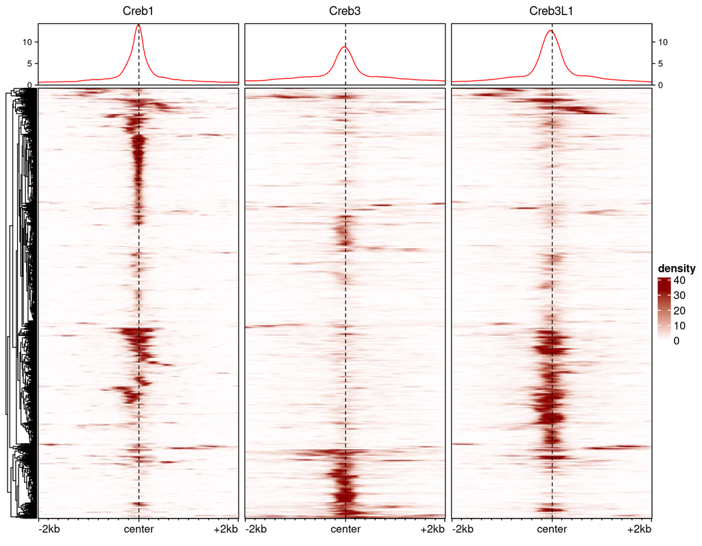

```r
epiwraps::plotEnrichedHeatmaps(
  ese,
  cluster_rows = TRUE,
  show_row_dend = TRUE,
  colors = c("white", "darkred")
)
```

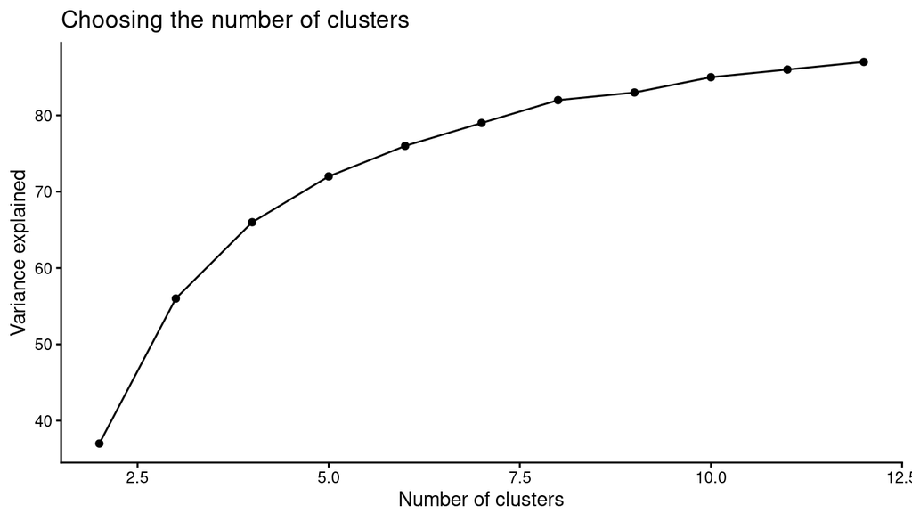

```r
set.seed(123)
cl_range <- epiwraps::clusterSignalMatrices(ese, k = 2:12)

ggplot(cl_range$varExplained, aes(k, varExplained)) +
  geom_line() +
  geom_point() +
  labs(
    x = "Number of clusters",
    y = "Variance explained",
    title = "Choosing the number of clusters"
  ) +
  theme_classic()
```

```r
set.seed(123)
cl <- epiwraps::clusterSignalMatrices(ese, k = 6, scaleRows = TRUE)
```

```
##   ~93% of the variance explained by clusters
```

```r
rowData(ese)$cluster <- factor(cl)

table(rowData(ese)$cluster)
```

```
##
##   1   2   3   4   5   6
## 292 488 602 226 517 144
```

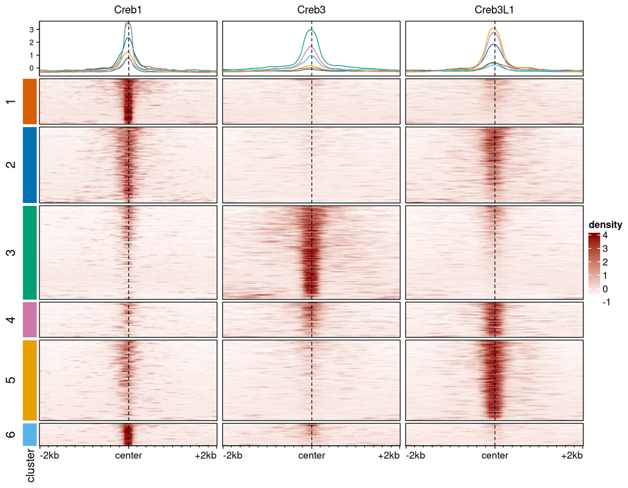

```r
cluster_colors <- c(
  "1" = "#D55E00",
  "2" = "#0072B2",
  "3" = "#009E73",
  "4" = "#CC79A7",
  "5" = "#E69F00",
  "6" = "#56B4E9"
)

epiwraps::plotEnrichedHeatmaps(
  ese,
  row_split = "cluster",
  scale_rows = "global",
  mean_color = cluster_colors,
  colors = c("white", "darkred")
)
```

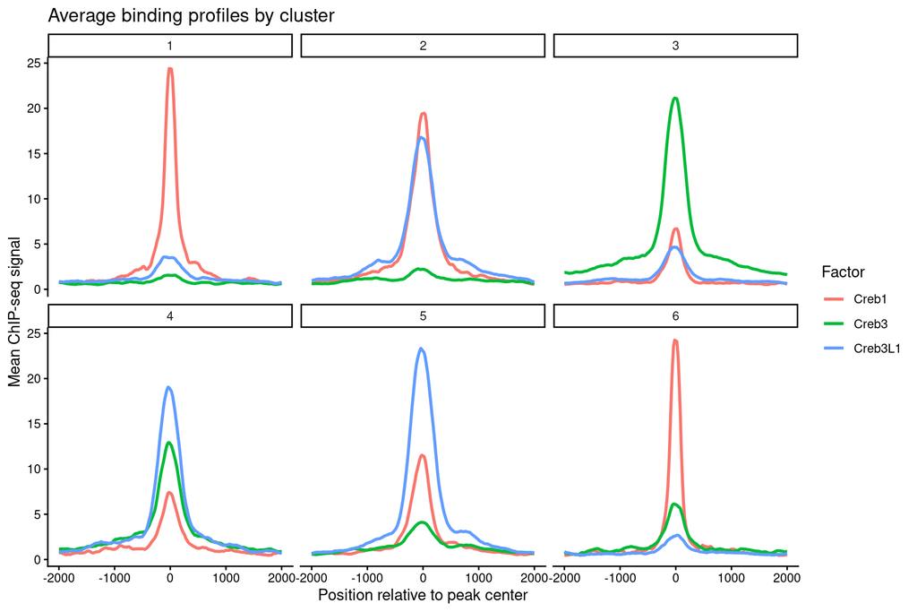

```r
cluster_means <- epiwraps::meltSignals(ese, splitBy = rowData(ese)$cluster)

ggplot(cluster_means, aes(position, mean, colour = sample)) +
  geom_line(linewidth = 1) +
  facet_wrap(~split) +
  labs(
    x = "Position relative to peak center",
    y = "Mean ChIP-seq signal",
    colour = "Factor",
    title = "Average binding profiles by cluster"
  ) +
  theme_classic()
```

## Part 3: Gene Ontology enrichment

```r
split_regions <- split(rowRanges(ese), rowData(ese)$cluster)
lengths(split_regions)
```

```
##   1   2   3   4   5   6
## 292 488 602 226 517 144
```

```r
enrichment_tables <- lapply(names(split_regions), function(cluster_id) {
  res <- rGREAT::great(
    split_regions[[cluster_id]],
    gene_sets = "GO:BP",
    tss_source = "hg38",
    background = regions,
    cores = 2
  )

  tab <- rGREAT::getEnrichmentTables(res)
  tab[order(tab$p_adjust, tab$p_adjust_hyper), ]
})

names(enrichment_tables) <- names(split_regions)

enrichment_summary <- do.call(rbind, lapply(names(enrichment_tables), function(cluster_id) {
  tab <- enrichment_tables[[cluster_id]]

  data.frame(
    cluster = cluster_id,
    n_regions = length(split_regions[[cluster_id]]),
    top_term = tab$description[1],
    fold_enrichment = tab$fold_enrichment[1],
    p_adjust = tab$p_adjust[1],
    p_adjust_hyper = tab$p_adjust_hyper[1]
  )
}))

enrichment_summary
```

```
##   cluster n_regions                                              top_term
## 1       1       292                           cellular component assembly
## 2       2       488                                            cell cycle
## 3       3       602                                    cell communication
## 4       4       226                                       tRNA processing
## 5       5       517               pyrimidine nucleotide metabolic process
## 6       6       144 regulation of receptor signaling pathway via JAK-STAT
##   fold_enrichment     p_adjust p_adjust_hyper
## 1        1.441501 1.197497e-02    0.012281838
## 2        1.143745 9.999867e-01    0.004718432
## 3        1.225584 5.332851e-06    0.001120935
## 4        3.952262 6.986087e-02    0.258499631
## 5        3.123299 9.999846e-01    0.500229021
## 6        5.229594 1.613402e-01    0.227488630
```

```r
cluster_for_enrichment <- as.character(
  enrichment_summary$cluster[which.min(enrichment_summary$p_adjust)]
)

bp <- enrichment_tables[[cluster_for_enrichment]]
bp <- bp[order(bp$p_adjust, bp$p_adjust_hyper), ]

cluster_for_enrichment
```

```
## [1] "3"
```

```r
length(split_regions[[cluster_for_enrichment]])
```

```
## [1] 602
```

```r
head(bp, 10)
```

```
##            id                    description genome_fraction
## 3  GO:0007154             cell communication       0.5069115
## 5  GO:0023052                      signaling       0.5093256
## 1  GO:0051716  cellular response to stimulus       0.5728734
## 4  GO:0001775                cell activation       0.1321753
## 2  GO:0002376          immune system process       0.2576506
## 6  GO:0045321           leukocyte activation       0.1274130
## 7  GO:0050896           response to stimulus       0.6387589
## 8  GO:0006955                immune response       0.1733406
## 9  GO:0050794 regulation of cellular process       0.7668011
## 11 GO:0007165            signal transduction       0.4754505
##    observed_region_hits fold_enrichment      p_value     p_adjust mean_tss_dist
## 3                   374        1.225584 1.068330e-08 5.332851e-06        120873
## 5                   375        1.223036 1.307071e-08 5.332851e-06        121022
## 1                   414        1.200453 4.590853e-09 5.332851e-06        119719
```

[output cut: 29 more lines]

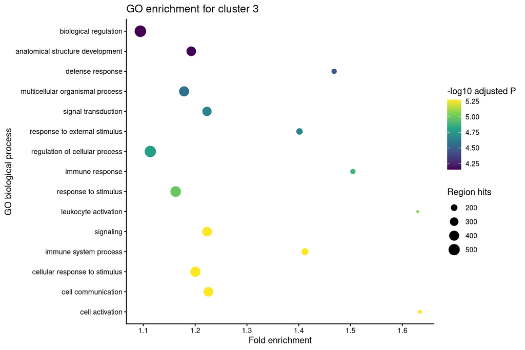

```r
top_bp <- head(bp, 15)

ggplot(
  top_bp,
  aes(fold_enrichment, reorder(description, p_adjust),
      size = observed_region_hits, color = -log10(p_adjust))
) +
  geom_point() +
  scale_color_viridis_c() +
  labs(
    x = "Fold enrichment",
    y = "GO biological process",
    size = "Region hits",
    color = "-log10 adjusted P",
    title = paste("GO enrichment for cluster", cluster_for_enrichment)
  ) +
  theme_classic()
```

## Results

```r
cluster_sizes <- table(rowData(ese)$cluster)
largest_cluster <- names(cluster_sizes)[which.max(cluster_sizes)]
top_terms <- paste(head(bp$description, 3), collapse = ", ")

cat(
  "After filtering the CREB-family peak sets for high-confidence peaks, I obtained ",
  length(regions),
  " non-redundant chromosome 1 regions. I clustered the ChIP-seq signal over these regions into six groups, with cluster ",
  largest_cluster,
  " being the largest (",
  max(cluster_sizes),
  " regions). The average profile plot showed both protein-specific groups and groups where multiple CREB-family factors were enriched at the same regions, indicating that the three factors do not occupy all high-confidence regions in the same way. Cluster 1 was mainly enriched for CREB1, cluster 2 showed CREB1 and CREB3L1 together, cluster 3 was mainly enriched for CREB3, cluster 4 showed all three factors with the strongest signal for CREB3L1 followed by CREB3 and CREB1, cluster 5 showed CREB3L1 followed by CREB1 and weaker CREB3 signal, and cluster 6 was also CREB1-enriched but with a different balance of CREB3 and CREB3L1 compared with cluster 1. I compared GO Biological Process enrichment across all six clusters and selected cluster ",
  cluster_for_enrichment,
  " for detailed visualization because it had the smallest adjusted enrichment P-value. The top enriched GO Biological Process terms in this cluster included ",
  top_terms,
  ". Because cluster ",
  cluster_for_enrichment,
  " showed stronger CREB3 signal than the other CREB-family factors, these results suggest that CREB3-bound regions may be associated with genes involved in cell communication and signaling-related processes.",
  sep = ""
)
```

After filtering the CREB-family peak sets for high-confidence peaks, I obtained 2269 non-redundant chromosome 1 regions. I clustered the ChIP-seq signal over these regions into six groups, with cluster 3 being the largest (602 regions). The average profile plot showed both protein-specific groups and groups where multiple CREB-family factors were enriched at the same regions, indicating that the three factors do not occupy all high-confidence regions in the same way. Cluster 1 was mainly enriched for CREB1, cluster 2 showed CREB1 and CREB3L1 together, cluster 3 was mainly enriched for CREB3, cluster 4 showed all three factors with the strongest signal for CREB3L1 followed by CREB3 and CREB1, cluster 5 showed CREB3L1 followed by CREB1 and weaker CREB3 signal, and cluster 6 was also CREB1-enriched but with a different balance of CREB3 and CREB3L1 compared with cluster 1. I compared GO Biological Process enrichment across all six clusters and selected cluster 3 for detailed visualization because it had the smallest adjusted enrichment P-value. The top enriched GO Biological Process terms in this cluster included cell communication, signaling, cellular response to stimulus. Because cluster 3 showed stronger CREB3 signal than the other CREB-family factors, these results suggest that CREB3-bound regions may be associated with genes involved in cell communication and signaling-related processes.